# Untitled

## Setting up

```r
set.seed(101) #generate random numbers / set the seed no matter how many times you generate
sample_n(iris, 10)
```

```
##    Sepal.Length Sepal.Width Petal.Length Petal.Width    Species
## 1           6.3         2.5          4.9         1.5 versicolor
## 2           6.3         3.3          4.7         1.6 versicolor
## 3           5.6         2.7          4.2         1.3 versicolor
## 4           6.5         3.0          5.2         2.0  virginica
## 5           5.0         2.0          3.5         1.0 versicolor
## 6           6.6         2.9          4.6         1.3 versicolor
## 7           5.1         2.5          3.0         1.1 versicolor
## 8           6.1         3.0          4.9         1.8  virginica
## 9           7.4         2.8          6.1         1.9  virginica
## 10          5.4         3.4          1.5         0.4     setosa
```

## Preparing the Data

That is to separate the data into two subsets; a training set and a testing set. We will use the training set to build our predictive model and then we will use our testing set to evaluate the accuracy of that model.

```r
trainingsample <- sample(c(TRUE, FALSE), nrow(iris), replace=T, prob=c(0.6, 0.4))
train <- iris[trainingsample,] #60%
test <- iris[!trainingsample,] #40%
```

## Linear Discriminant Analysis

LDA looks for linear combination of the independent variables to best explain the data and predict the different classes. Discriminant scores are calculated for each observation for each class based on these linear combinations

I need to check the equation.

```r
lda.iris <- lda(Species ~., train)
lda.iris
```

```
## Call:
## lda(Species ~ ., data = train)
##
## Prior probabilities of groups:
##     setosa versicolor  virginica
##  0.3095238  0.3214286  0.3690476
##
## Group means:
##            Sepal.Length Sepal.Width Petal.Length Petal.Width
## setosa         5.019231    3.396154     1.453846   0.2423077
## versicolor     5.948148    2.814815     4.381481   1.3925926
## virginica      6.641935    2.912903     5.609677   1.9645161
##
## Coefficients of linear discriminants:
##                     LD1       LD2
## Sepal.Length  1.2366962 -1.082723
## Sepal.Width   0.8121037 -1.397630
## Petal.Length -2.3838963  1.172088
## Petal.Width  -2.6747723 -2.295058
##
## Proportion of trace:
##    LD1    LD2
## 0.9963 0.0037
```

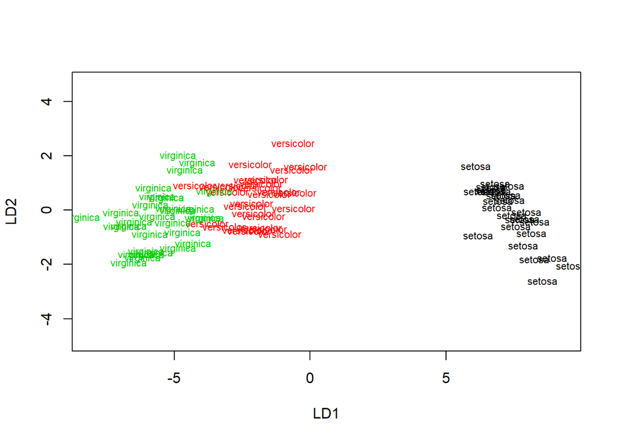

```r
plot(lda.iris, col=as.integer(train$Species))
```

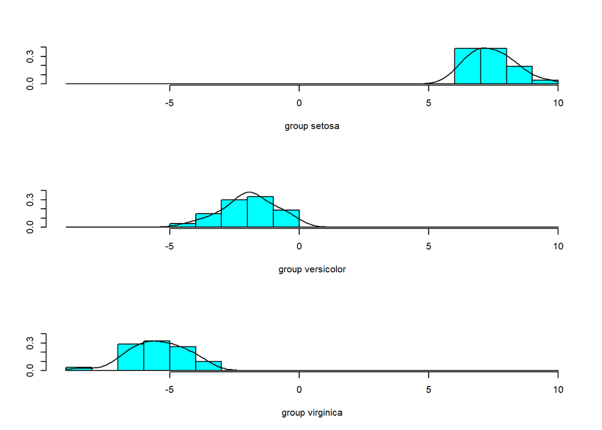

```r
plot(lda.iris, dimen = 1, type="b")
```

## LDA Partition Plots

Using the partimat function from the klaR Package provides an alternative way to plot the linear discriminant functions. partimat outouts an array of plots for every combination of two variables. This of each plot as a different view of the same data. Coloured regions delineate each classification area. Any observation that falls within a region is predicted to be from a specific class. Each plot also includes the apprent error rate for that view of the data.

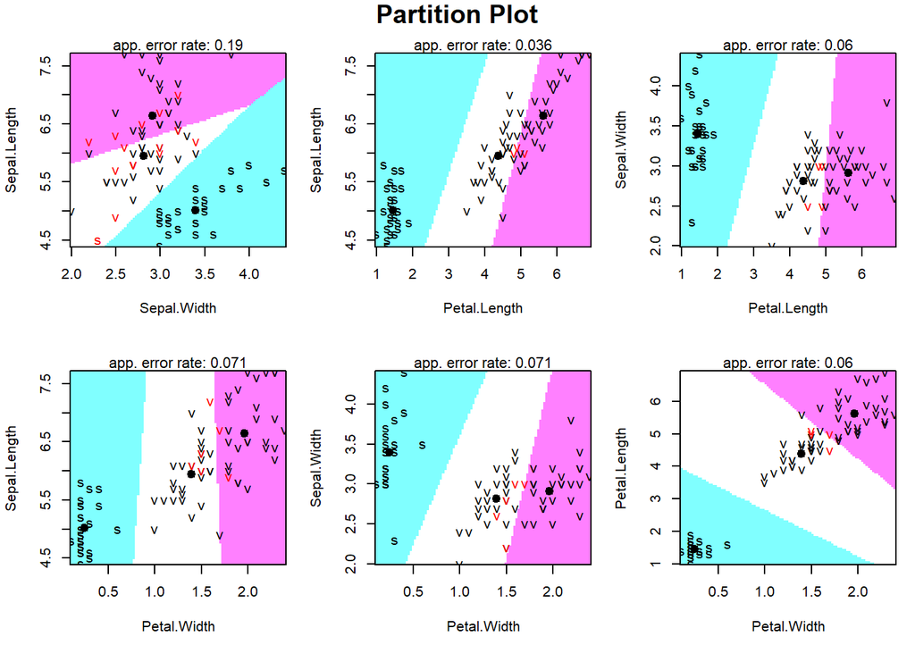

```r
partimat(Species ~ Sepal.Length + Sepal.Width + Petal.Length + Petal.Width, data=train, method="lda")
```

## LDA Predictions

```r
lda.train <- predict(lda.iris)

train$lda <- lda.train$class
table(train$lda, train$Species)
```

```
##
##              setosa versicolor virginica
##   setosa         26          0         0
##   versicolor      0         25         1
##   virginica       0          2        30
```

The total number of correctly predicted observations is the sum of the diagonal. (26+25+30) So this model fit the training data correctyl for almost every observation.

```r
lda.test <- predict(lda.iris, test)
test$lda <- lda.test$class
table(test$lda, test$Species)
```

```
##
##              setosa versicolor virginica
##   setosa         24          0         0
##   versicolor      0         23         0
##   virginica       0          0        19
```

Based on the model we created (lda.iris), lda.iris will predict the response variable with an accuracy of 100%.